# Analysis of the Effect of Transmission Type on Vehicle MPG

Amir Manafpour

5/7/2020

## Executive Summary

This study evalautes the affect of the type of transmission on the miles per gallon (mpg) value of the vehicles in the mtcars dataset. The results show when running regressional analyssis with MPG as the outcume and only the “am” variable as the predictor: a 7.25 increase in MPG for automatic transmission versus manual transmission is observed with a very low p-value.

However, by incorporating more relevant variables such as wt and hp, the am (transmission type) variable becomes statisically insignficant. This implies that the MPG value of vehicles doesn’t depend on transmission type and that other variables can better explain the variability in MPG values.

## Exploratory Data Analysis

```r
data("mtcars")
df <- mtcars
head(df)
```

|  | mpg | cyl | disp | hp | drat | wt | qsec | vs | am | gear | carb |
| --- | --- | --- | --- | --- | --- | --- | --- | --- | --- | --- | --- |
| Mazda RX4 | 21.0 | 6 | 160 | 110 | 3.90 | 2.620 | 16.46 | 0 | 1 | 4 | 4 |
| Mazda RX4 Wag | 21.0 | 6 | 160 | 110 | 3.90 | 2.875 | 17.02 | 0 | 1 | 4 | 4 |
| Datsun 710 | 22.8 | 4 | 108 | 93 | 3.85 | 2.320 | 18.61 | 1 | 1 | 4 | 1 |
| Hornet 4 Drive | 21.4 | 6 | 258 | 110 | 3.08 | 3.215 | 19.44 | 1 | 0 | 3 | 1 |
| Hornet Sportabout | 18.7 | 8 | 360 | 175 | 3.15 | 3.440 | 17.02 | 0 | 0 | 3 | 2 |
| Valiant | 18.1 | 6 | 225 | 105 | 2.76 | 3.460 | 20.22 | 1 | 0 | 3 | 1 |

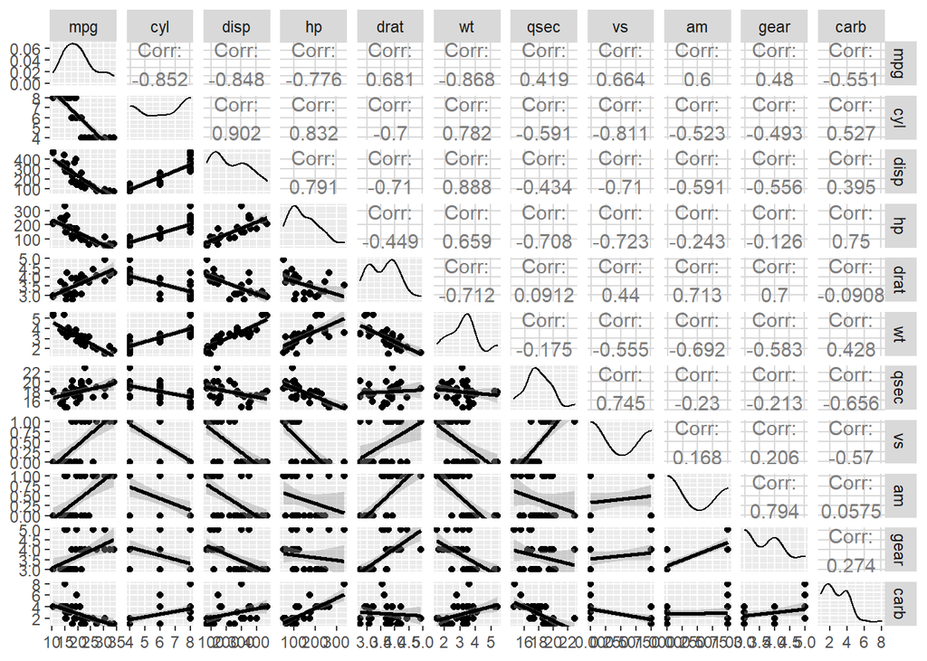

```r
ggpairs(df, lower = list(continuous = "smooth"))
```

Based on the correlation values we observe the following:

- Continuous variables: mpg, disp, hp, drat, wt, qsec
- Discreate variables: vs, am, gear, carb, cyl
- High correlation (>= 0.6) between mpg and -> cyl, disp, hp, drat, wt, vs, am
- But a lot of the variables themselves are highly correlated to each other also

## Regression Analysis

First a model was fit using all variables and by considering cyl, vs, am, and gear variables as factors.

```r
fit <- lm(mpg ~ factor(cyl) + disp + hp + drat + wt + qsec + factor(vs) + factor(am) + factor(gear) + carb, data = df)
summary(fit)
```

```
##
## Call:
## lm(formula = mpg ~ factor(cyl) + disp + hp + drat + wt + qsec +
##     factor(vs) + factor(am) + factor(gear) + carb, data = df)
##
## Residuals:
##     Min      1Q  Median      3Q     Max
## -3.2015 -1.2319  0.1033  1.1953  4.3085
##
## Coefficients:
##               Estimate Std. Error t value Pr(>|t|)
## (Intercept)   15.09262   17.13627   0.881   0.3895
## factor(cyl)6  -1.19940    2.38736  -0.502   0.6212
## factor(cyl)8   3.05492    4.82987   0.633   0.5346
## disp           0.01257    0.01774   0.708   0.4873
## hp            -0.05712    0.03175  -1.799   0.0879 .
## drat           0.73577    1.98461   0.371   0.7149
## wt            -3.54512    1.90895  -1.857   0.0789 .
## qsec           0.76801    0.75222   1.021   0.3201
## factor(vs)1    2.48849    2.54015   0.980   0.3396
## factor(am)1    3.34736    2.28948   1.462   0.1601
## factor(gear)4 -0.99922    2.94658  -0.339   0.7382
## factor(gear)5  1.06455    3.02730   0.352   0.7290
## carb           0.78703    1.03599   0.760   0.4568
## ---
## Signif. codes:  0 '***' 0.001 '**' 0.01 '*' 0.05 '.' 0.1 ' ' 1
##
## Residual standard error: 2.616 on 19 degrees of freedom
## Multiple R-squared:  0.8845, Adjusted R-squared:  0.8116
## F-statistic: 12.13 on 12 and 19 DF,  p-value: 1.764e-06
```

Based on the results above, it appears weight and horsepower seems to have the lowest p-values compared to all the other variables, followed by the transmission variable (am).

To compare models, we’ll start out with a model only including am, then add in the wt variable, followed by the hp variable.

wt-hp have high correlation (0.659) and so do wt-am = (-.692) so we’ll include the interaction of these variables also for comparison purposes.

```r
fit1 <- lm(mpg ~ factor(am), data = df)
fit2 <- lm(mpg ~ factor(am) + wt, data = df)
fit2i <- lm(mpg ~ factor(am)*wt, data = df)
fit3 <- lm(mpg ~ wt + hp + factor(am), data = df)
fit3i <- lm(mpg ~ wt*hp + wt*factor(am), data = df)

summary(fit1)
```

```
##
## Call:
## lm(formula = mpg ~ factor(am), data = df)
##
## Residuals:
##     Min      1Q  Median      3Q     Max
## -9.3923 -3.0923 -0.2974  3.2439  9.5077
##
## Coefficients:
##             Estimate Std. Error t value Pr(>|t|)
## (Intercept)   17.147      1.125  15.247 1.13e-15 ***
## factor(am)1    7.245      1.764   4.106 0.000285 ***
## ---
## Signif. codes:  0 '***' 0.001 '**' 0.01 '*' 0.05 '.' 0.1 ' ' 1
##
## Residual standard error: 4.902 on 30 degrees of freedom
## Multiple R-squared:  0.3598, Adjusted R-squared:  0.3385
## F-statistic: 16.86 on 1 and 30 DF,  p-value: 0.000285
```

```r
summary(fit2)
```

```
##
## Call:
## lm(formula = mpg ~ factor(am) + wt, data = df)
##
## Residuals:
##     Min      1Q  Median      3Q     Max
## -4.5295 -2.3619 -0.1317  1.4025  6.8782
##
## Coefficients:
##             Estimate Std. Error t value Pr(>|t|)
## (Intercept) 37.32155    3.05464  12.218 5.84e-13 ***
## factor(am)1 -0.02362    1.54565  -0.015    0.988
## wt          -5.35281    0.78824  -6.791 1.87e-07 ***
## ---
## Signif. codes:  0 '***' 0.001 '**' 0.01 '*' 0.05 '.' 0.1 ' ' 1
##
## Residual standard error: 3.098 on 29 degrees of freedom
## Multiple R-squared:  0.7528, Adjusted R-squared:  0.7358
## F-statistic: 44.17 on 2 and 29 DF,  p-value: 1.579e-09
```

```r
summary(fit3)
```

```
##
## Call:
## lm(formula = mpg ~ wt + hp + factor(am), data = df)
##
## Residuals:
##     Min      1Q  Median      3Q     Max
## -3.4221 -1.7924 -0.3788  1.2249  5.5317
##
## Coefficients:
##              Estimate Std. Error t value Pr(>|t|)
## (Intercept) 34.002875   2.642659  12.867 2.82e-13 ***
## wt          -2.878575   0.904971  -3.181 0.003574 **
## hp          -0.037479   0.009605  -3.902 0.000546 ***
## factor(am)1  2.083710   1.376420   1.514 0.141268
## ---
## Signif. codes:  0 '***' 0.001 '**' 0.01 '*' 0.05 '.' 0.1 ' ' 1
##
## Residual standard error: 2.538 on 28 degrees of freedom
## Multiple R-squared:  0.8399, Adjusted R-squared:  0.8227
## F-statistic: 48.96 on 3 and 28 DF,  p-value: 2.908e-11
```

```r
anova(fit1, fit2, fit3)
```

|  | Res.Df | RSS | Df | Sum of Sq | F | Pr(>F) |
| --- | --- | --- | --- | --- | --- | --- |
| 1 | 30 | 720.8966 | NA | NA | NA | NA |
| 2 | 29 | 278.3197 | 1 | 442.57690 | 68.73415 | 5.070618e-09 |
| 3 | 28 | 180.2911 | 1 | 98.02863 | 15.22428 | 5.464023e-04 |

```r
anova(fit1, fit2i, fit3i)
```

|  | Res.Df | RSS | Df | Sum of Sq | F | Pr(>F) |
| --- | --- | --- | --- | --- | --- | --- |
| 1 | 30 | 720.8966 | NA | NA | NA | NA |
| 2 | 28 | 188.0077 | 2 | 532.88893 | 53.570167 | 6.006593e-10 |
| 3 | 26 | 129.3174 | 2 | 58.69024 | 5.900002 | 7.713641e-03 |

## Model Selection

The model only considering am as a variable (fit1) has an estimated coefficient of 7.25 for the am = 1 factor. Which would imply that automatic transmission (am = 1) has an MPG of about 7.25 higher versus manual transmission (am = 0). The p-value for fit1 also implies that the “am” variable is a statistically significant variable. However, the R-squared value is only 0.36 which implies a significan portion of the variation in MPG cannot be explained by the “am” variable alone.

By adding in the wt and hp variables, we see p-values significanly less than 0.05 by running ANOVA on the 3 nested models. The same occurs when we run the ANOVA on models including the interaction of variables too. The R-squared value for models (fit2 + fit3) including wt and hp variables are significantly higher (>0.75) which implies a lot more of the variance in MPG can be explained by including the wt and hp variables.

For fit2 and fit3 models the am variable becomes statiscally insignificant with p-values of 0.988 and 0.141 respectively. Ultimately this analysis implies that the type of transmission is statistically insignifcant compared to horsepower and weight.

## Residuals Diagnostics

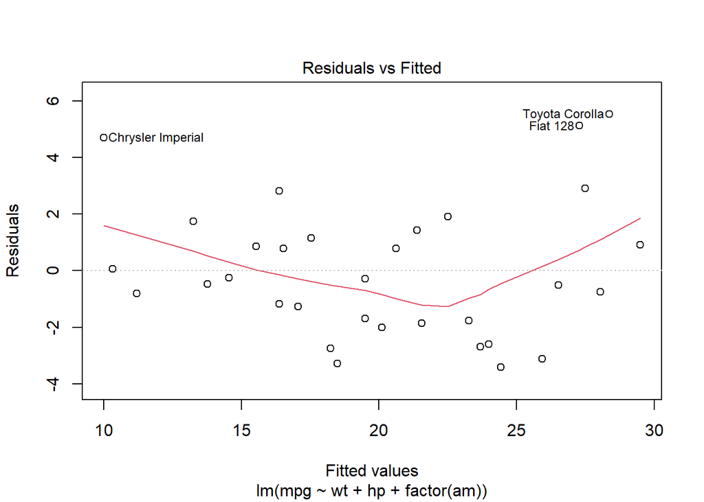

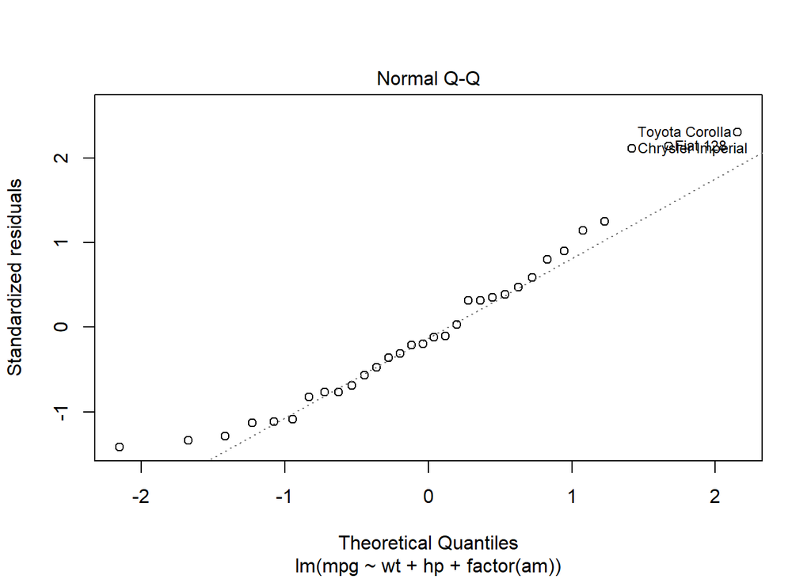

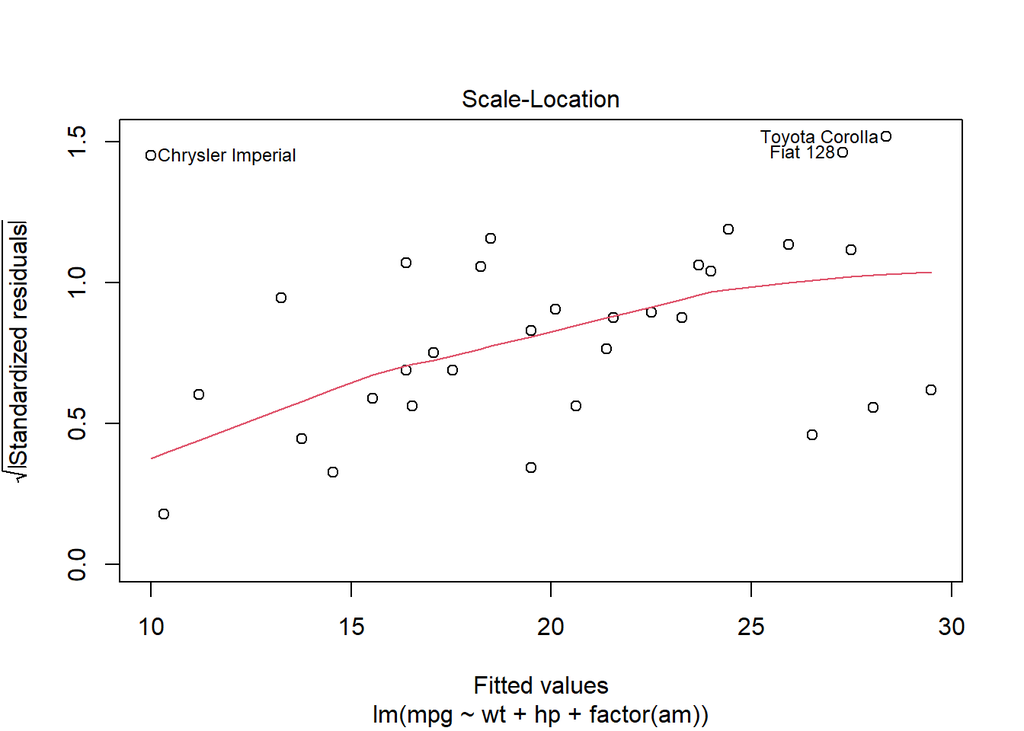

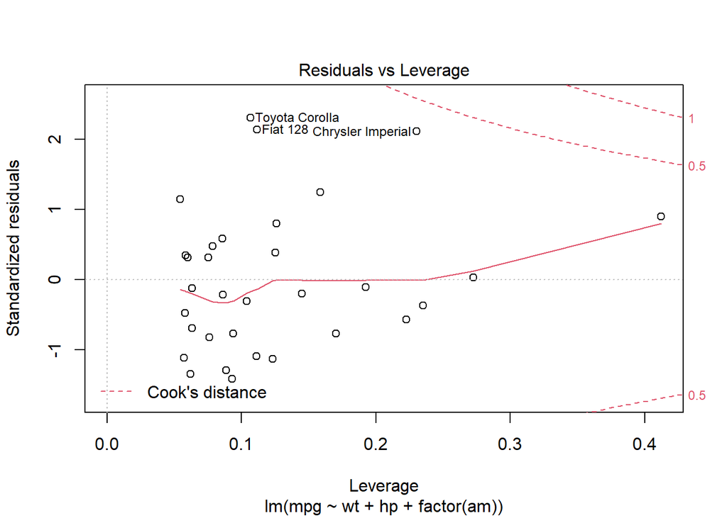

```r
plot(fit3)
```